# Age of Return

Markdown for Figures 1 - 3

Caitlin O’Brien

1/4/2023

Basefile wrangling

```r
#packages
library(tidyverse)
library(likert)
library(lubridate)

#import data
d<-read_csv("data_adults.csv")

d<- d %>%
   mutate_if(sapply(d,is.character), as.factor)
summary(d)

##filter data
df<- d %>%
  filter(length < 155,##remove fork length > 155mm for all types--removes two values (162 & 164mm, t_run = 2) plus 6 NA's
         juv_lgr_first > '1998-01-01 00:00:00' & juv_lgr_first < '2019-12-31 24:00:00',## only include 1998 to 2019 juv_lgr_first data.
         pass_type_T_R  %in% c("ROR", "T")) #filter to only include ROR and T--removes RORBD (3) and TB (4) values

#extract smolt migration year ()
d.smy<-df %>%
  mutate_if(sapply(d,is.character), as.factor) %>%
  mutate(smy_year = lubridate::year(juv_lgr_first))
```

## Figure 1. Return Numbers

Number of smolts and adults by age vs smolt migration year.

[likert plot](https://r-graph-gallery.com/202-barplot-for-likert-type-items.html) ~ where mini-jacks and jacks are on the left, and 2-ocean, 3-ocean, etc. are on the right.

- summarize data to include age grouping based on age column:
  - mini-jack (0-ocean)
  - jack (1-ocean)
  - 2-ocean
  - 3-ocean
  - 4-ocean or more.

figure 1 data wrangling:

```r
#calculate ocean age--needs updating
d.ocean<-d.smy %>%
  filter(!is.na(adu_bon_first)) %>% #removed any adu_bon without detection----REDO this to include past adu_first data (need code)
  mutate(years_diff = time_length(difftime(adu_bon_first, juv_lgr_first), "years")) %>%  # Calculate difference in years
  mutate(ReturnAge = case_when(years_diff <1 ~ '0-Ocean', #assign value based on years_diff ( plotted strict casewhen, but updated to reflect age that grouped (i.e. 2.5 = 3yrs, see graph of years_diff to see breakdown))
                              years_diff >=1 & years_diff < 1.5 ~'1-Ocean',
                              years_diff >=1.5 & years_diff < 2.5 ~'2-Ocean',
                              years_diff >=2.5 & years_diff < 3.5 ~'3-Ocean',
                              years_diff >= 3.5 & years_diff <5 ~'4-Ocean'))

#summarize data by return age
d.return<- d.ocean %>%
  mutate_if(sapply(d.ocean,is.character), as.factor) %>%
  group_by(t_run, pass_type_T_R, smy_year, ReturnAge) %>%
  summarise( n = n())
```

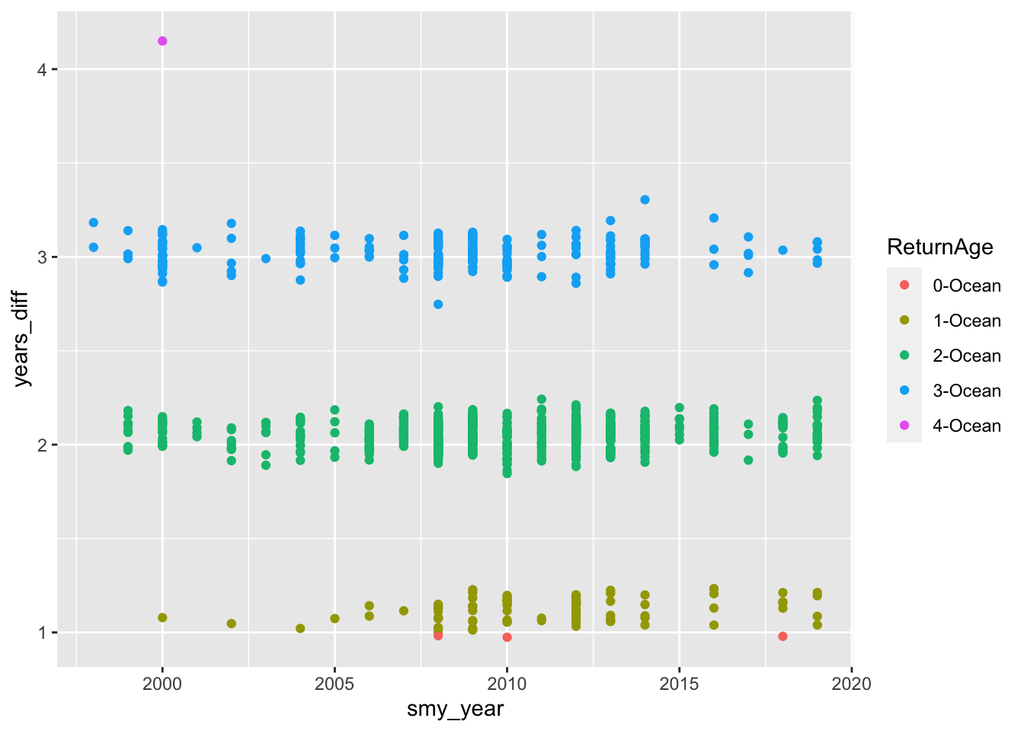

```r
 #show breakdown of age by years_diff
    ggplot(d.ocean, aes(x=smy_year, y= years_diff, color=ReturnAge))+
      geom_point()
```

### Figure 1a

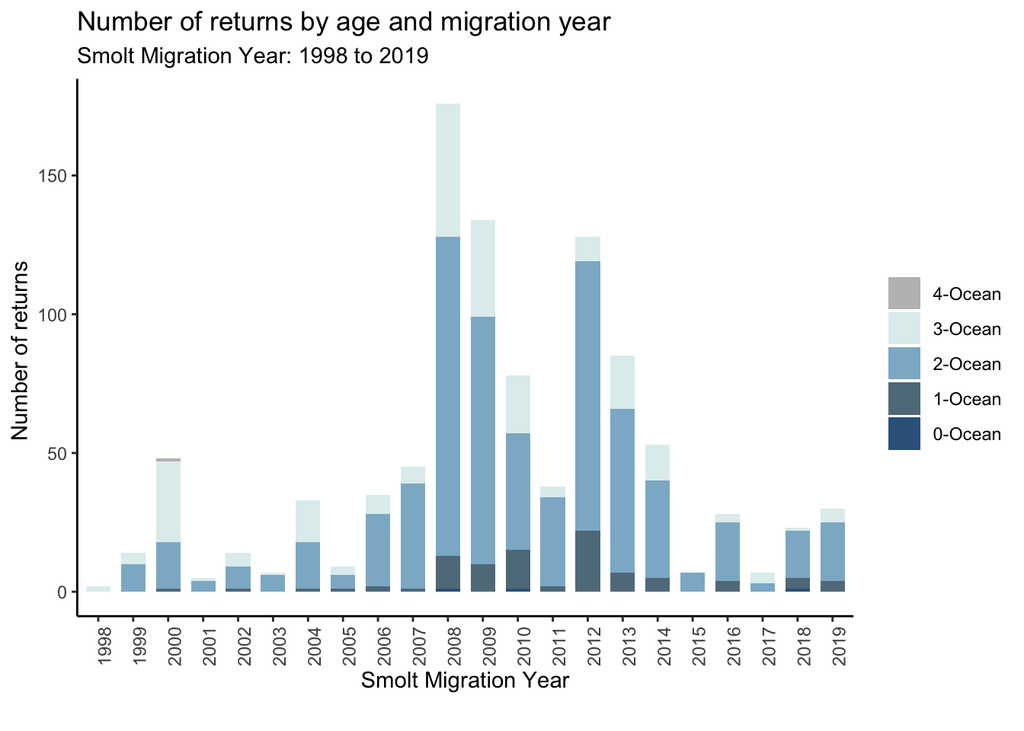

```r
#stacked bar of counts
ggplot(d.return, aes(x=as.factor(smy_year), y= n, fill=forcats::fct_rev(ReturnAge)))+
  geom_bar(position = "stack", stat="identity", width = .7)+
  labs(x="Smolt Migration Year", y= "Number of returns ",
       color="",
       fill ="",
       title = "Number of returns by age and migration year",
       subtitle = "Smolt Migration Year: 1998 to 2019",
       caption = "")+
  scale_fill_manual(breaks = c("4-Ocean", "3-Ocean", "2-Ocean", "1-Ocean", "0-Ocean"),
                       values =c("gray","azure2","lightskyblue3", "lightskyblue4","steelblue4"))+
  theme_classic()+
  theme(axis.text.x = element_text(angle = 90))
```

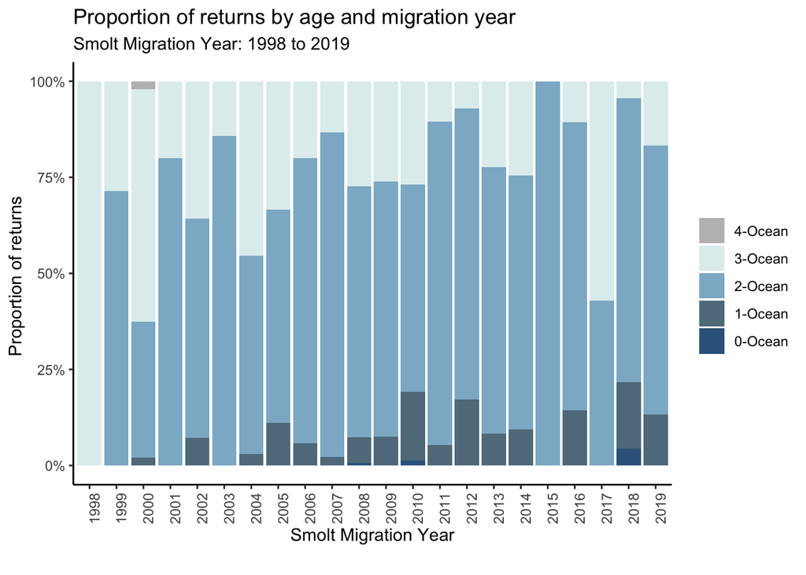

```r
#proportional stacked bar
ggplot(d.return, aes(x=as.factor(smy_year), y= n, fill=forcats::fct_rev(ReturnAge)))+
  geom_bar(position = position_fill(), stat="identity")+
  labs(x="Smolt Migration Year", y= "Proportion of returns ",
       color="",
       fill ="",
       title = "Proportion of returns by age and migration year",
       subtitle = "Smolt Migration Year: 1998 to 2019",
       caption = "")+
  scale_fill_manual(breaks = c("4-Ocean", "3-Ocean", "2-Ocean", "1-Ocean", "0-Ocean"),
                       values =c("gray","azure2","lightskyblue3", "lightskyblue4","steelblue4"))+
  scale_y_continuous(labels = scales::percent)+
  theme_classic()+
  theme(axis.text.x = element_text(angle = 90))
```

### Figure 1b.

Same as Figure 1a, with transported vs in-river juvenile fish categories distinguished.

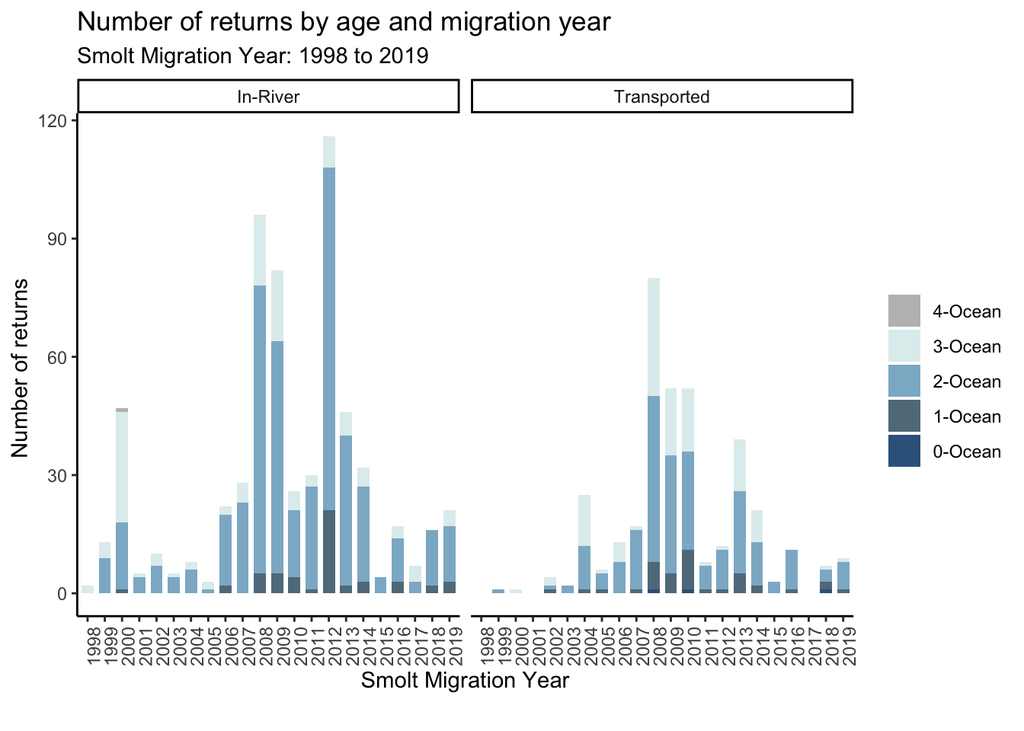

```r
#labels for facet grid
p.labs <- c("In-River", "Transported")
names(p.labs) <- c("ROR", "T")

#stacked bar with pass_type
ggplot(d.return, aes(x=as.factor(smy_year), y= n, fill=forcats::fct_rev(ReturnAge)))+
  geom_bar(position = "stack", stat="identity", width = .7)+
  labs(x="Smolt Migration Year", y= "Number of returns ",
       color="",
       fill ="",
       title = "Number of returns by age and migration year",
       subtitle = "Smolt Migration Year: 1998 to 2019",
       caption = "")+
  scale_fill_manual(breaks = c("4-Ocean", "3-Ocean", "2-Ocean", "1-Ocean", "0-Ocean"),
                       values =c("gray","azure2","lightskyblue3", "lightskyblue4","steelblue4"))+
  theme_classic()+
  theme(axis.text.x = element_text(angle = 90)) + facet_grid(~pass_type_T_R, labeller = labeller(pass_type_T_R = p.labs))
```

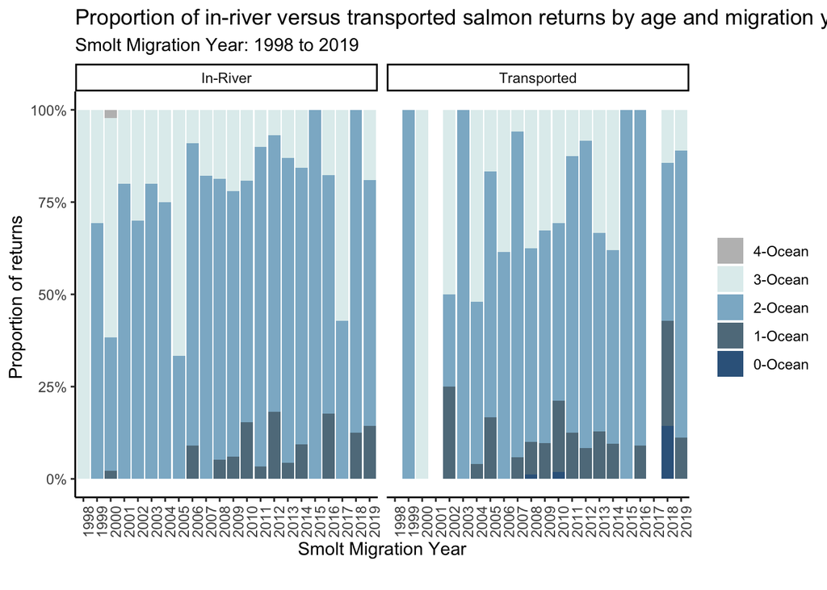

```r
#proportional stacked bar with transport and ROR

ggplot(d.return, aes(x=as.factor(smy_year), y= n, fill=forcats::fct_rev(ReturnAge)))+
  geom_bar(position = position_fill(), stat="identity")+
  labs(x="Smolt Migration Year", y= "Proportion of returns ",
       color="",
       fill ="",
       title = "Proportion of in-river versus transported salmon returns by age and migration year",
       subtitle = "Smolt Migration Year: 1998 to 2019",
       caption = "")+
   scale_fill_manual(breaks = c("4-Ocean", "3-Ocean", "2-Ocean", "1-Ocean", "0-Ocean"),
                       values =c("gray","azure2","lightskyblue3", "lightskyblue4","steelblue4"))+
  scale_y_continuous(labels = scales::percent)+
  theme_classic()+
  theme(axis.text.x = element_text(angle = 90)) + facet_grid(~pass_type_T_R, labeller = labeller(pass_type_T_R = p.labs))
```

Likert (like) plot

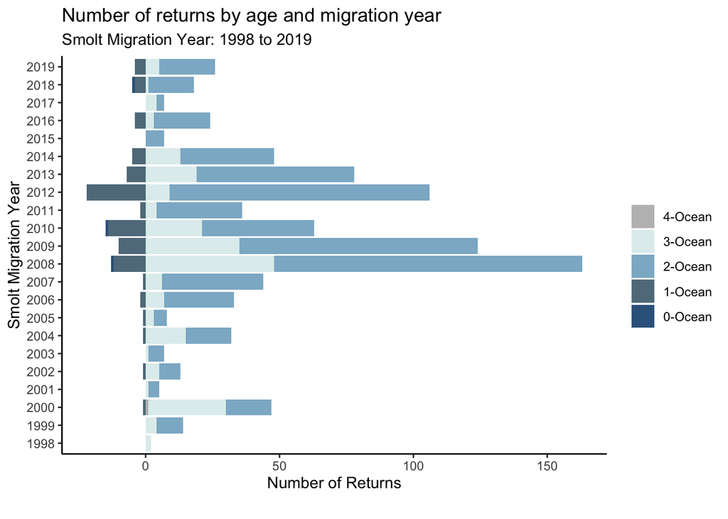

```r
#subset and graph two times
ggplot(d.return, aes(x=as.factor(smy_year), fill=ReturnAge)) +
      geom_bar(data = subset(d.return, ReturnAge %in% c("0-Ocean","1-Ocean")),
               aes(y = -n), position="stack", stat="identity") +
      geom_bar(data = subset(d.return, !ReturnAge %in% c("0-Ocean","1-Ocean")),
               aes(y = n), position="stack", stat="identity")+
    labs(x="Smolt Migration Year", y= "Number of Returns",
       color="",
       fill ="",
       title = "Number of returns by age and migration year",
       subtitle = "Smolt Migration Year: 1998 to 2019",
       caption = "")+
    scale_fill_manual(breaks = c("4-Ocean", "3-Ocean", "2-Ocean", "1-Ocean", "0-Ocean"),
                       values =c("gray","azure2","lightskyblue3", "lightskyblue4","steelblue4"))+
  coord_flip() + theme_classic()
```

## Figure 2. Fork Length

### Figure 2a.

Fork length vs smolt migration year [boxplot or violin plot, including outliers](https://r-graph-gallery.com/violin.html)

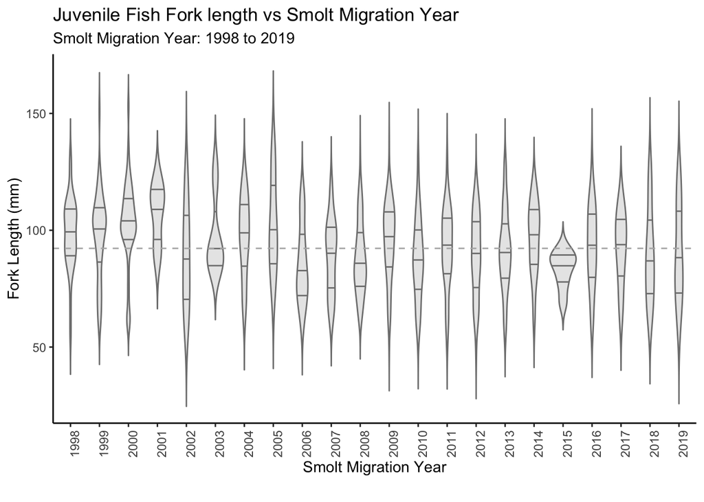

```r
fig.2a<-ggplot(d.smy, aes(x=as.factor(smy_year), y=length)) +
  geom_violin(draw_quantiles = c(0.25, 0.5, 0.75),
              alpha=.2,
              color = "grey50",
              fill = "grey50",
              trim = FALSE )+
   geom_hline(yintercept=mean(d.smy$length),
              linetype="dashed",
              color = "grey70",
              linewidth = .5)+
  #geom_point(alpha=.25, color = "grey40", size = 1) +
  labs(x="Smolt Migration Year",
       y= "Fork Length (mm)",
       color=" ",
      title = "Juvenile Fish Fork length vs Smolt Migration Year",
      subtitle = "Smolt Migration Year: 1998 to 2019",
      caption = "")+
  theme_classic()+
  theme (legend.position = "bottom",
         axis.text.x = element_text(angle = 90))

fig.2a
```

### Figure 2b.

Transported vs in-river juvenile fish Fork length vs smolt migration year Same as Figure 2a, with categories distinguished.

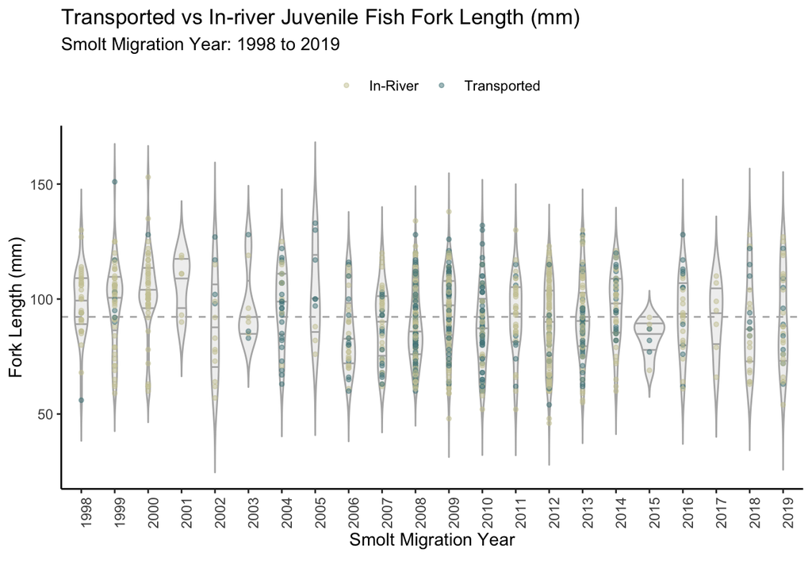

```r
fig.2b<-ggplot(d.smy, aes(x=as.factor(smy_year), y=length)) +
  geom_violin(draw_quantiles = c(0.25, 0.5, 0.75),
              alpha=.2,
              color = "grey70",
              fill = "grey70",
              trim = FALSE )+
   geom_hline(yintercept=mean(d.smy$length),
              linetype="dashed",
              color = "grey70",
              linewidth = .5)+
  geom_point(alpha=.5, size = 1, aes(color=pass_type_T_R)) +
  labs(x="Smolt Migration Year", y= "Fork Length (mm)",
       color="",
       title = "Transported vs In-river Juvenile Fish Fork Length (mm)",
       subtitle = "Smolt Migration Year: 1998 to 2019",
       caption = "")+
  scale_color_manual(breaks = c("ROR", "T"),
                     labels = c("In-River", "Transported"),
                     values = c("lemonchiffon3", "cadetblue4"))+
  theme_classic()+
  theme (legend.position = "top",
                          axis.text.x = element_text(angle = 90))

fig.2b
```

### Alternatives

Alternative 2b: Individual violin graphs separated by transport type

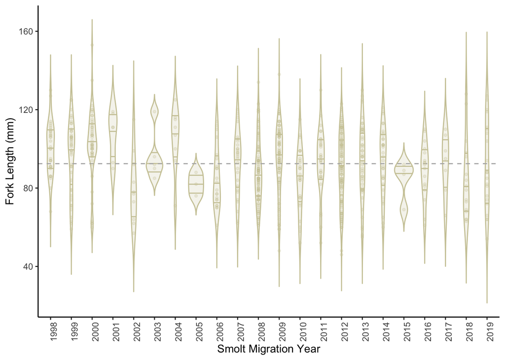

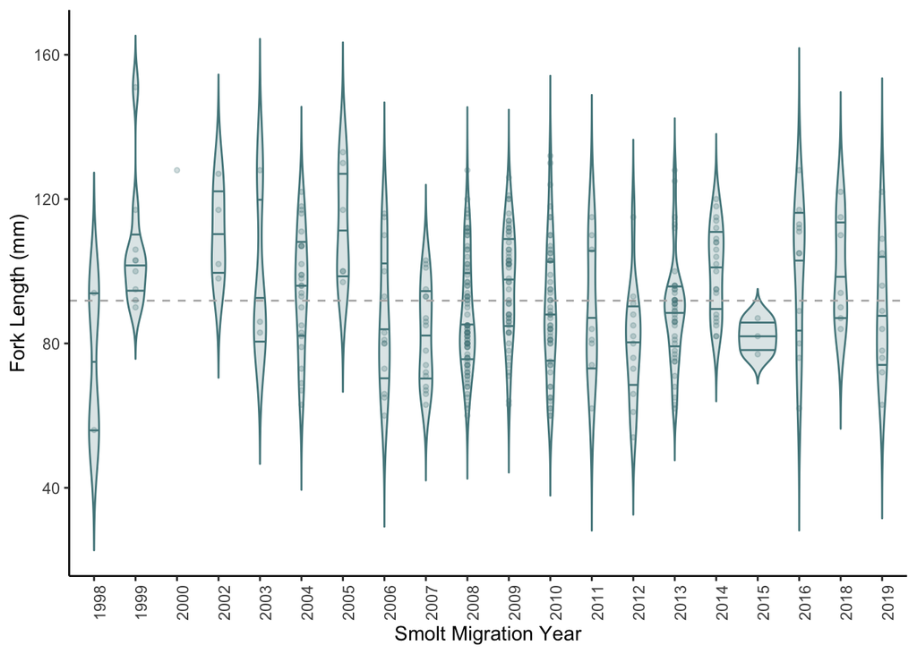

Alternative 2b: Side-by-side of Transport and ROR violin graphs

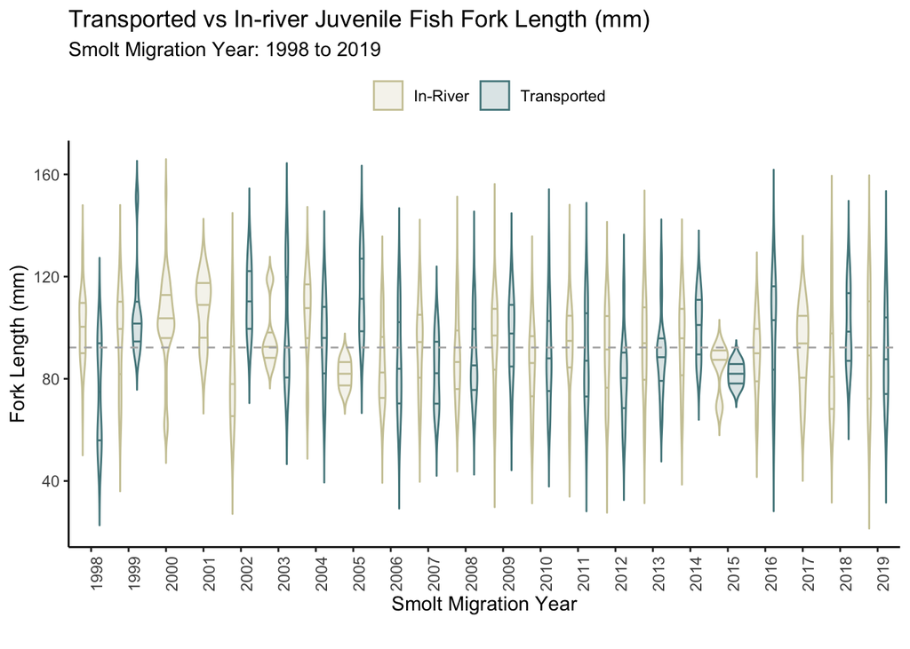

Alternative 2b: using ridges

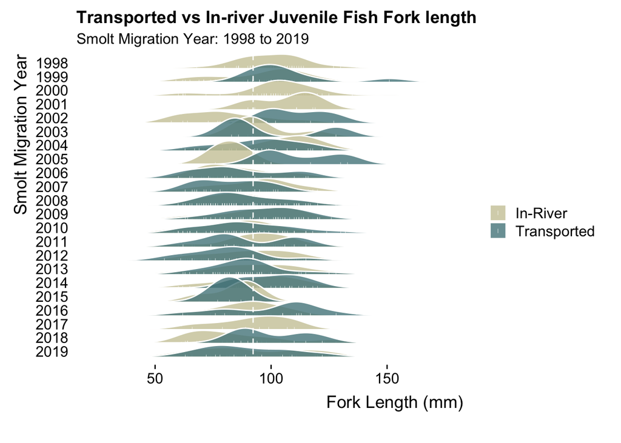

## Figure 3. Release Location

figure 3 data wrangling

```r
##group and summarize to get count of returns per year>subbasin>pass_type

d.rel <-d.smy %>%
  group_by(smy_year, subbasin, pass_type_T_R) %>%
  summarise( count = n())
```

### Figure 3a.

Proportion by release location vs. year [stream graph](https://r-graph-gallery.com/streamgraph.html) or [stacked area chart](https://r-graph-gallery.com/stacked-area-graph.html)

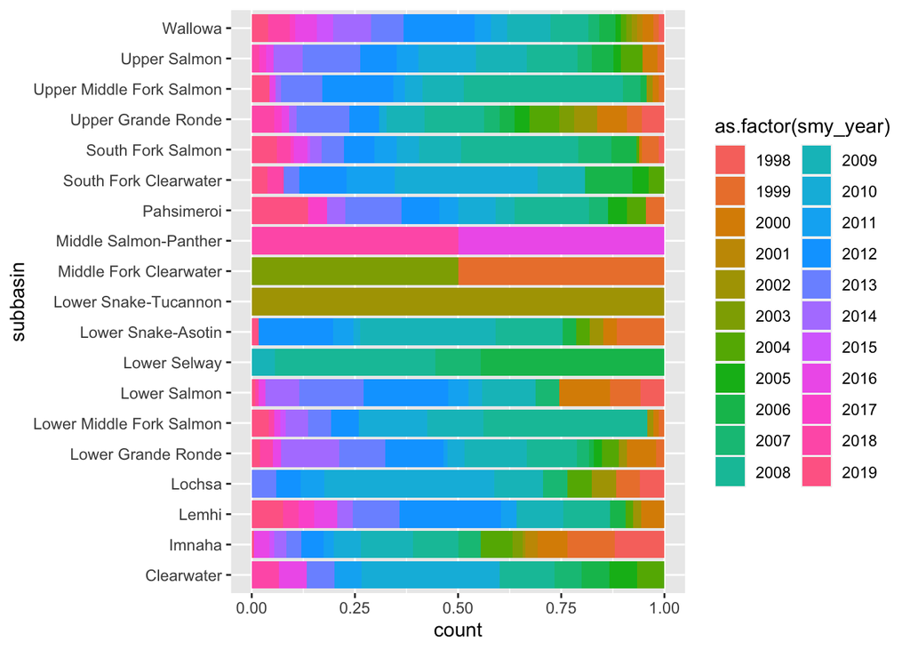

```r
# bar
ggplot(d.rel, aes(x=subbasin, y= count, fill=as.factor(smy_year)))+
  geom_bar(position = "fill", stat="identity")+
  coord_flip()
```

### Figure 3b.

Proportion by release location vs. year of transported vs in-river juvenile fish Same as Figure 3a, with transported vs in-river juvenile fish categories distinguished.

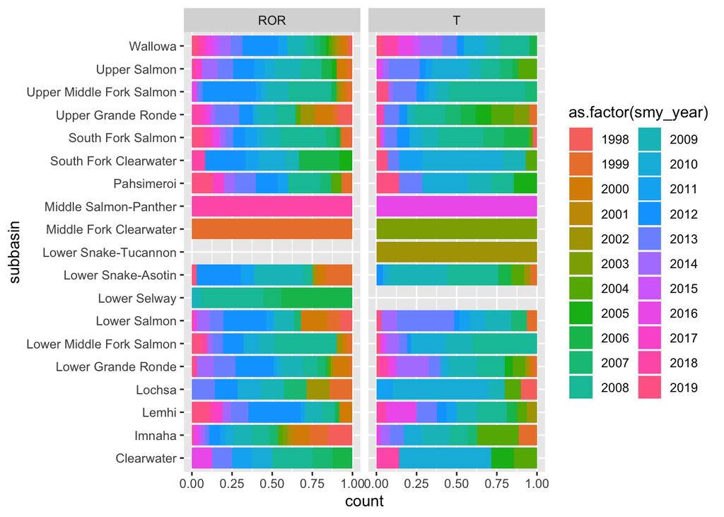

```r
ggplot(d.rel, aes(x=subbasin, y= count, fill=as.factor(smy_year)))+
  geom_bar(position = "fill", stat="identity")+
  coord_flip()+ facet_grid(~pass_type_T_R)
```